# Final project: Exploring Beijing Taxis GPS data

Jeevan Giddaluru

19/06/2021

#### Observations

The project **“Exploring Beijing Taxis GPS data”** is submitted as the final project for the course Análise de Dados para as Ciências Sociais (FLS6397) offered at the Department of Political Science, University of São Paulo. The project is developed based on the principles and techniques discussed in the course, prioritizing the clarity and organization of the script and the good practices of data science and programming. Therefore, certain parts of the analysis consider simple assumptions and may not represent the actual complexity of a scientific problem. The project instructions are found [here](https://jonnyphillips.github.io/Ciencia_de_Dados/projeto.html). **The complete project and instructions for reproducibility are available on [Github](https://github.com/jeevgidd/FLS6397-Final-Project).**

### 1. Introduction

Global Positioning System (GPS) technology has revolutionized the fields of mapping and navigation. The present-day industries such as aviation, marine, surveying, and military have been extensively using the services offered by GPS technology. Its application in transportation systems has become widespread for the past two decades, mainly by the introduction of in-vehicle GPS facilities that allowed effective navigation and monitoring of vehicle location. As GPS-enabled smartphones have become mainstream, services such as route guidance, analyzing traffic movements, estimating fast routes, and predicting travel duration became commercially viable.

In the current project, we explore the location history data of taxis in the Beijing municipality recorded from February 2 to February 8, 2008. The original data set published by Microsoft consists of trajectories of 33,000 taxis, and a sample of 10,357 taxi trajectories are available on the [Microsoft website](https://www.microsoft.com/en-us/research/publication/t-drive-trajectory-data-sample/) (Yuan et al. 2011b) (Yuan et al. 2011a). We begin with analyzing and exploring a single taxi trajectory and finally perform aggregate analysis of a few taxi trajectories. The aggregate analysis will not include the data of 10,357 taxis because of the computational limitations.

#### Important definitions

1. **Stay location:** Stay location is defined as a location where the taxi waited for at least a certain duration.
2. **Trip:** A trip is defined as a set of GPS points recorded during the travel between one stay location to another stay location.
3. **Stay point:** Stay points are the GPS points recorded inside a stay location.
4. **Moving point:** A moving point is one of the GPS points recorded during the travel between one stay location to another stay location.

**A stay location consists of multiple stay points and a trip consists of multiple moving points.**

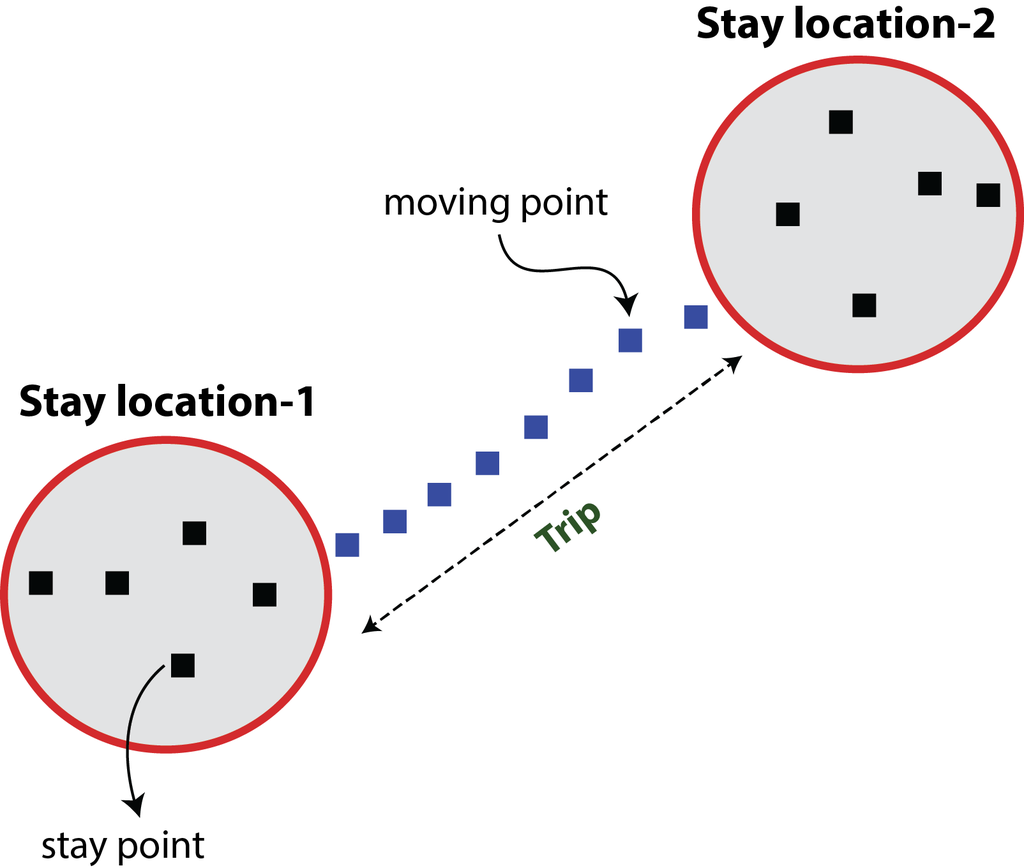

Schematic representation

### 2. Objectives

1. **Analysis of an individual taxi trajectory**
   - Calculate the distance between the consecutive GPS points in an individual taxi trajectory. Subsequently, calculate the speeds with which the taxi traveled from one point to another.
   - Classify the GPS points of the trajectory into stay or moving points.
   - Aggregate and label the stay points and moving points into stay locations and trips.
   - Calculate trip duration, speed and identify pickup and drop hours of each trip performed by the taxi.
   - Calculate the stay duration at each stay location and classify them.
   - Visualize the different stay locations and moving points on an interactive map.
2. **Aggregate analysis of multiple taxi trajectories**
   - To import multiple taxi trajectories and repeat the analysis as performed above.
   - Generate aggregated stay location tables and trip tables.
   - Visualize the aggregated stay locations on a map.
   - Identify the district with the highest taxi waiting points.
   - Identify the total number of trips done on each day of the week and each part of the day.
   - Determine the percentage distribution of trips based on the trip duration on each day of the week.
   - Develop a Least Squares Regression Model based on trip distance and trip duration, and predict the trip duration.

### 3. Analysis

First, we load the required options for our R session. We turn off the scientific notation and assign value 10 to the “pillar.sigfig” option. This allows us to distinguish the decimals of latitude and longitude values. We also load the necessary libraries for our analysis.

```r
# loads required options
options(pillar.sigfig = 10)     # number of digits to appear in a tibble
options(scipen=999)             # turnoff scientific notation
```

```r
#load required libraries
library(rmarkdown)          #install.packages("rmarkdown")
library(knitr)              #install.packages("knitr")
library(tidyverse)          #install.packages("tidyverse")
library(sf)                 #install.packages("sf")
library(lwgeom)             #install.packages("lwgeom")
library(ggplot2)            #install.packages("ggplot2")
library(scales)             #install.packages("scales")
library(lubridate)          #install.packages("lubridate")
library(hms)                #install.packages("hms")
library(broom)              #install.packages("broom")
library(DT)                 #install.packages("DT")
library(mapview)            #install.packages("mapview")
library(ggpubr)             #install.packages("ggpubr")
library(tmaptools)          #install.packages("tmaptools")
library(stargazer)          #install.packages("stargazer")
library(Zelig)              #install.packages("Zelig")
```

**Individual Analysis**

The GPS trajectory file of each taxi contains four columns (refer to user guide available in the taxi_data folder).

1. Taxi ID
2. Date and time when the coordinates were recorded
3. Longitude
4. Latitude

The data is ordered by the date and time column. First, we only import and work with data from one taxi (TAXI 48) and assign the respective column names.

```r
# imports only one taxi file (48.txt) data from taxi_data folder.
# separator and column names are assigned as necessary (refer user_guide.pdf)

taxi <- read_delim("taxi_data/48.txt",
                   delim = ",", col_names = FALSE) %>%
  set_names(c("taxi_id","date_time","longitude","latitude"))

taxi
```

| taxi_id | date_time | longitude | latitude |
| --- | --- | --- | --- |
| 48 | 2008-02-02 13:38:07 | 116.4520 | 39.92732 |
| 48 | 2008-02-02 13:48:07 | 116.4392 | 39.94952 |
| 48 | 2008-02-02 13:57:07 | 116.4297 | 39.96330 |
| 48 | 2008-02-02 14:01:58 | 116.4332 | 39.96016 |
| 48 | 2008-02-02 14:11:59 | 116.4593 | 39.98671 |
| 48 | 2008-02-02 14:13:32 | 116.4609 | 39.98813 |
| 48 | 2008-02-02 14:23:32 | 116.4777 | 39.97511 |
| 48 | 2008-02-02 14:26:50 | 116.4813 | 39.96982 |
| 48 | 2008-02-02 14:42:24 | 116.4319 | 39.93992 |
| 48 | 2008-02-02 14:45:12 | 116.4264 | 39.93995 |

[output cut: 895 more lines]

We check if the trajectory has duplicated GPS records. Duplicate rows imply the same coordinates recorded at the same time. We use the **distinct()** function to eliminate the duplicated rows.

```r
# excludes duplicated rows (coordinates recorded at the same time).
taxi_df1 <- taxi %>% distinct()

b <- nrow(taxi_df1) #number of rows after applying distinct
a <- nrow(taxi) #number of rows in original data set
```

42 observations (rows) were identified as duplicated GPS records. Therefore we use the new tibble without the duplicated rows for the rest of our analysis. We also add a new column consisting of row numbers which serve as unique ID numbers for our GPS records.

```r
taxi_df1 <- taxi_df1 %>%
  mutate(data_id = row_number()) %>%                        # creates new column with row numbers
  select(data_id, taxi_id, date_time, longitude, latitude)  # saves the tibble with columns in a respective order

head(taxi_df1)
```

| data_id | taxi_id | date_time | longitude | latitude |
| --- | --- | --- | --- | --- |
| 1 | 48 | 2008-02-02 13:38:07 | 116.4520 | 39.92732 |
| 2 | 48 | 2008-02-02 13:48:07 | 116.4392 | 39.94952 |
| 3 | 48 | 2008-02-02 13:57:07 | 116.4297 | 39.96330 |
| 4 | 48 | 2008-02-02 14:01:58 | 116.4332 | 39.96016 |
| 5 | 48 | 2008-02-02 14:11:59 | 116.4593 | 39.98671 |
| 6 | 48 | 2008-02-02 14:13:32 | 116.4609 | 39.98813 |

We extract the year, month, day, complete-time, only hours, only minutes, and only seconds information from the date_time column, and save each one of them in a new column. For this, we use the **hms** library functions. In addition, we save the day of the week information (Monday to Sunday) in a new column using the date from the date_time column.

```r
taxi_df1 <- taxi_df1 %>%
  mutate(time = as_hms(date_time),              # extracts and saves only time from data_time column
         year = year(date_time),                # extracts and saves only year as numeric
         month = month(date_time),              # extracts and saves only month as numeric
         day = day(date_time),                  # extracts and saves only day as numeric
         hours = hour(date_time),               # extracts and saves only hours as numeric
         minutes = minute(date_time),           # extracts and saves only minutes as numeric
         seconds = second(date_time),           # extracts and saves only seconds as numeric

         # identifies day of the week based on the date
         # format = "%w": Numbers 0 to 6 are assigned to day of the week (0-Sunday, 1-Monday and so on...6-Saturday)
         day_of_week = format(date_time,
                              format = "%w"),

         # identifies day of the week based on the date
         #format = "%A": name of the day of the week
         day_of_week_full = format(date_time,
                              format = "%A")
         )

head(taxi_df1)
```

| data_id | taxi_id | date_time | longitude | latitude | time | year | month | day | hours | minutes | seconds | day_of_week | day_of_week_full |
| --- | --- | --- | --- | --- | --- | --- | --- | --- | --- | --- | --- | --- | --- |
| 1 | 48 | 2008-02-02 13:38:07 | 116.4520 | 39.92732 | 13:38:07 | 2008 | 2 | 2 | 13 | 38 | 7 | 6 | sábado |
| 2 | 48 | 2008-02-02 13:48:07 | 116.4392 | 39.94952 | 13:48:07 | 2008 | 2 | 2 | 13 | 48 | 7 | 6 | sábado |
| 3 | 48 | 2008-02-02 13:57:07 | 116.4297 | 39.96330 | 13:57:07 | 2008 | 2 | 2 | 13 | 57 | 7 | 6 | sábado |
| 4 | 48 | 2008-02-02 14:01:58 | 116.4332 | 39.96016 | 14:01:58 | 2008 | 2 | 2 | 14 | 1 | 58 | 6 | sábado |
| 5 | 48 | 2008-02-02 14:11:59 | 116.4593 | 39.98671 | 14:11:59 | 2008 | 2 | 2 | 14 | 11 | 59 | 6 | sábado |
| 6 | 48 | 2008-02-02 14:13:32 | 116.4609 | 39.98813 | 14:13:32 | 2008 | 2 | 2 | 14 | 13 | 32 | 6 | sábado |

We then use **st_as_sf** function from the **sf** library to convert the tibble into an sf object which uses the longitude and latitude values to create a geometry column.

```r
#creates geometry using "longitude" and "latitude" columns and assigns CRS as 4326 since the values are in degrees
#remove FALSE makes sure that the original columns are not deleted

taxi_df2 <- taxi_df1 %>%
    st_as_sf(coords=c("longitude", "latitude"), crs=4326, remove = FALSE)

head(taxi_df2)
```

| data_id | taxi_id | date_time | longitude | latitude | time | year | month | day | hours | minutes | seconds | day_of_week | day_of_week_full | geometry |
| --- | --- | --- | --- | --- | --- | --- | --- | --- | --- | --- | --- | --- | --- | --- |
| 1 | 48 | 2008-02-02 13:38:07 | 116.4520 | 39.92732 | 13:38:07 | 2008 | 2 | 2 | 13 | 38 | 7 | 6 | sábado |  |
| 2 | 48 | 2008-02-02 13:48:07 | 116.4392 | 39.94952 | 13:48:07 | 2008 | 2 | 2 | 13 | 48 | 7 | 6 | sábado |  |
| 3 | 48 | 2008-02-02 13:57:07 | 116.4297 | 39.96330 | 13:57:07 | 2008 | 2 | 2 | 13 | 57 | 7 | 6 | sábado |  |
| 4 | 48 | 2008-02-02 14:01:58 | 116.4332 | 39.96016 | 14:01:58 | 2008 | 2 | 2 | 14 | 1 | 58 | 6 | sábado |  |
| 5 | 48 | 2008-02-02 14:11:59 | 116.4593 | 39.98671 | 14:11:59 | 2008 | 2 | 2 | 14 | 11 | 59 | 6 | sábado |  |
| 6 | 48 | 2008-02-02 14:13:32 | 116.4609 | 39.98813 | 14:13:32 | 2008 | 2 | 2 | 14 | 13 | 32 | 6 | sábado |  |

We calculate the distances traveled between consecutive GPS points. In other words, the distance at the first GPS point is 0 and at the second GPS point is the distance traveled between the first and second GPS points and so on. We also calculate the time taken to reach a GPS point from the previously recorded GPS point. Using the ‘distance’ and ‘time taken’ values, we calculate the speed with which the taxi traveled between the GPS points. For distance calculation, we use **st_distance** function and for time difference, we use **difftime** function. The distances are calculated in kilometers (km), time is calculated in hours (hr), and speed as km/hr.

| Column names | Description |
| --- | --- |
| distance | Distance traveled from the previous GPS point (km) |
| time_diff | Time taken to reach the current GPS point from the previous GPS point (hr) |
| speed | The speed with which the taxi reached the current GPS point (km/hr) |

```r
#function to calculate distance and speed from the geometries created in previous steps

distance_speed <- function(dff) {

  dff %>%

    # new column 'geometry_n': extracts from 2nd row to last row of geometry column (NA is assigned as last row)
    # calculates distance between the old geometry and new geometry columns: equivalent to calculating distance between row 1 and row 2 coordinates, row 2 and row 3, and so on in the geometry column
    # by 1000 saves distance in km
    mutate(geometry_n = geometry[row_number() + 1],
         distance = st_distance(geometry,
                                geometry_n,
                                by_element = TRUE)/1000) %>%

    # removes geometry_n column generated in previous step
    select(-geometry_n) %>%

    # moves distance column values one row ahead and saves the distance as numeric from meters units
    mutate(distance = as.numeric(lag(distance))) %>%

    # replaces 1st distance NA value with 0
    mutate_at("distance", ~replace(., is.na(.), 0)) %>%

    # the difference of time (in hours) is calculated between consecutive coordinates using the date_time column
    mutate(time_diff = difftime(date_time[row_number()+1],
                                date_time[row_number()],
                                units = "hours")) %>%

    # moves time difference values one row ahead and saves the time as numeric from hour units
    mutate(time_diff = as.numeric(lag(time_diff))) %>%

    # replaces 1st time difference NA value with 0
    mutate_at("time_diff", ~replace(., is.na(.), 0)) %>%

    # speed calculation
    mutate(speed = distance/time_diff) %>%

    # replaces 1st speed NAN value with 0
    mutate_at("speed", ~replace(., is.nan(.), 0))

}

# calculates distance speed on the tibble by using above function
taxi_df2 <- taxi_df2 %>%
  distance_speed()

head(taxi_df2)
```

| data_id | taxi_id | date_time | longitude | latitude | time | year | month | day | hours | minutes | seconds | day_of_week | day_of_week_full | geometry | distance | time_diff | speed |
| --- | --- | --- | --- | --- | --- | --- | --- | --- | --- | --- | --- | --- | --- | --- | --- | --- | --- |
| 1 | 48 | 2008-02-02 13:38:07 | 116.4520 | 39.92732 | 13:38:07 | 2008 | 2 | 2 | 13 | 38 | 7 | 6 | sábado |  | 0.0000000 | 0.00000000 | 0.000000 |
| 2 | 48 | 2008-02-02 13:48:07 | 116.4392 | 39.94952 | 13:48:07 | 2008 | 2 | 2 | 13 | 48 | 7 | 6 | sábado |  | 2.6993380 | 0.16666667 | 16.196028 |
| 3 | 48 | 2008-02-02 13:57:07 | 116.4297 | 39.96330 | 13:57:07 | 2008 | 2 | 2 | 13 | 57 | 7 | 6 | sábado |  | 1.7322678 | 0.15000000 | 11.548452 |
| 4 | 48 | 2008-02-02 14:01:58 | 116.4332 | 39.96016 | 14:01:58 | 2008 | 2 | 2 | 14 | 1 | 58 | 6 | sábado |  | 0.4586739 | 0.08083333 | 5.674316 |
| 5 | 48 | 2008-02-02 14:11:59 | 116.4593 | 39.98671 | 14:11:59 | 2008 | 2 | 2 | 14 | 11 | 59 | 6 | sábado |  | 3.6957234 | 0.16694444 | 22.137445 |
| 6 | 48 | 2008-02-02 14:13:32 | 116.4609 | 39.98813 | 14:13:32 | 2008 | 2 | 2 | 14 | 13 | 32 | 6 | sábado |  | 0.2119732 | 0.02583333 | 8.205415 |

Now we use **ggplot** library functions to plot the distance and speed through time on each day.

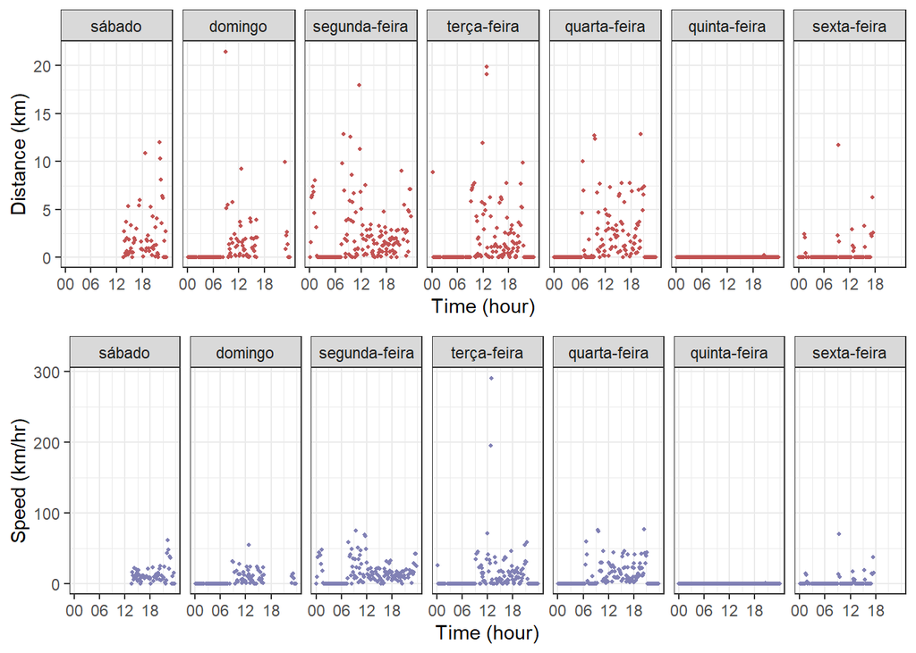

```r
#for labels in facet_grid
#named vector with day (in date) as names and day of the week as values
#example: For 2008-02-02: 2 - "Saturday", 2008-02-03: 3 - "Sunday" and so on

dates_day <- taxi_df1 %>%
  distinct(day, day_of_week_full) %>%
  deframe()


#distance vs time plot
distance_plot <- taxi_df2 %>%
    ggplot() +
    geom_point(aes(time, distance), colour = "#c25353", size = 0.75) + #plot as points with specific colour and size

    #breaks: generates a sequence from 0 to end value with 21600 seconds as increment value
    #labels: only hours
    scale_x_time(breaks = seq(0, max(as.numeric(taxi_df2$time)), 21600),
                 labels = scales::time_format("%H")) +
    ylab("Distance (km)") +
    xlab("Time (hour)") +

    #grouped by day column and arranged column-wise using dates_day named vector as labels
    facet_grid(cols=vars(day),
               labeller = labeller(.cols = dates_day)) +
    theme_bw()


#speed vs time plot
speed_plot <- taxi_df2 %>%
    ggplot() +
    geom_point(aes(time, speed), colour = "#8181b5", size = 0.75) + #plot as points with specific colour and size

    #breaks: generates a sequence from 0 to end value with 21600 seconds as increment value
    #labels: only hours
    scale_x_time(breaks = seq(0, max(as.numeric(taxi_df2$time)), 21600),
                 labels = scales::time_format("%H")) +
    ylab("Speed (km/hr)") +
    xlab("Time (hour)") +

    #grouped by day column and arranged column-wise using dates_day named vector as labels
    facet_grid(cols=vars(day),
               labeller = labeller(.cols = dates_day)) +
    theme_bw()


#combined plotting: distance and speed plot
gridExtra::grid.arrange(distance_plot, speed_plot, nrow=2)
```

We see the distance traveled and speed recorded by the taxi were comparatively less on Friday and near to 0 on Thursday. We can assume that in this particular week, the taxi driver might not have worked on Thursday. We see that the speed recorded on Tuesday reaches 300 km/hour, which seems unusual. The [speed limits](https://www.beijingesc.com/tips-on-driving-in-china/20-on-speed-limits.html) on the city express roads and expressways in Beijing are **100 km/hr** and **120 km/hr** respectively. We can safely assume that these points are outliers as the result of poor satellite signals. Therefore, we remove the points with a speed above 120 km/hr from the dataset and re-calculate the distances and speeds.

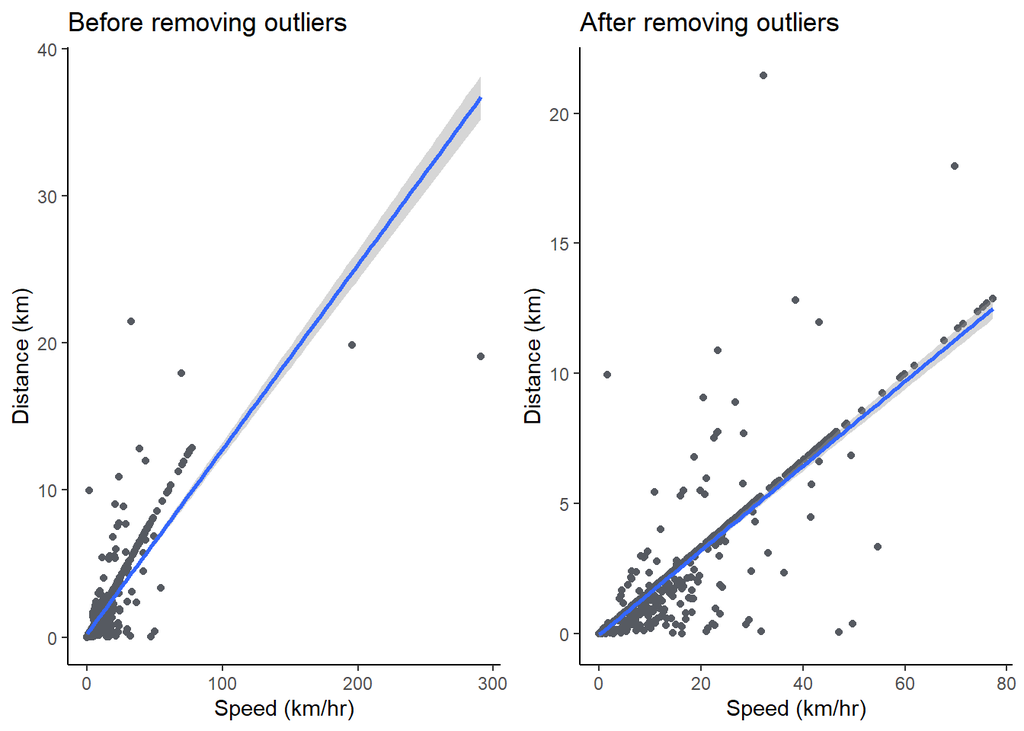

```r
#distance vs speed plot
plot_before <- taxi_df2 %>%
    ggplot() +
    geom_point(aes(speed, distance), colour = "#565a61") + #plot as points with specific colour

    #adds smoothing line
    geom_smooth(aes(speed, distance), method = lm) +
    ylab("Distance (km)") +
    xlab("Speed (km/hr)") +
    ggtitle("Before removing outliers") +
    theme_classic()


#removes values with speed more than 100 and re-calculates distance and speed using distance_speed function
taxi_df2 <- taxi_df2 %>%
  filter(speed < 120) %>%
  distance_speed()


#distance vs speed plot after filtering based on speed
plot_after <- taxi_df2 %>%
  ggplot() +
    geom_point(aes(speed, distance), colour = "#565a61") + #plot as points with specific colour

    #adds smoothing line
    geom_smooth(aes(speed, distance), method = lm) +
    ylab("Distance (km)") +
    xlab("Speed (km/hr)") +
    ggtitle("After removing outliers") +
    theme_classic()


#combined plotting: before and after filtering the data set based on speed
gridExtra::grid.arrange(plot_before, plot_after, ncol=2)
```

As we can see the distance versus speed linear model plotted before and after removing outliers, the latter one seems to fit better.

We now classify the GPS records into **stay points** and **moving points** (see definitions in the introduction) using the algorithm proposed in a paper published by [Microsoft](https://www.microsoft.com/en-us/research/publication/mining-user-similarity-based-on-location-history/) (Li et al. 2008). To assign a GPS point as a stay point, the algorithm uses two variables; distance and time difference.

In our project, we define a GPS point as a stay point if the distance traveled from the previous point is **less than or equal to 50 meters** and the time taken to reach this point is **up to 30 minutes**. We use time difference threshold of 30 minutes, as that Beijing municipality generally observes a heavy traffic (to avoid labeling moving points as stay points). The points other than the stay points are labeled as moving points.

```r
#function to identify if the recorded coordinates are staying or moving points

stay_moving <- function(df) {

  #if the distance traveled from previous point to existing point is less than 50 meters and the time to reach the existing point from previous point is less than 30 minutes
  df_2 <- df %>% filter(distance <= 0.05 & time_diff <=0.5) %>%
    mutate(type = "staying", #labels the points as staying
           stay_points = 0) #labels with 0 value


  #All the points other than the staying points are moving points
  df_1 <- df %>%
  filter(!(distance <= 0.05 & time_diff <=0.5)) %>%
    mutate(type = "moving", #labels the points as moving
           stay_points = -1) #labels with -1 value


  df <- bind_rows(df_1,df_2) %>% #combines the tables
  arrange(data_id) #arranges by data_id column so they are ordered

  return(df)

}

#apply stay_moving function to our taxi 48 table
taxi_df2 <- taxi_df2 %>%
  stay_moving()

taxi_df2 %>% select(data_id, distance, time_diff, type, stay_points) %>%
  st_drop_geometry()
```

|  | data_id | distance | time_diff | type | stay_points |
| --- | --- | --- | --- | --- | --- |
| 1 | 1 | 0.0000000000 | 0.0000000000 | staying | 0 |
| 2 | 2 | 2.6993379642 | 0.1666666667 | moving | -1 |
| 3 | 3 | 1.7322677912 | 0.1500000000 | moving | -1 |
| 4 | 4 | 0.4586738900 | 0.0808333333 | moving | -1 |
| 5 | 5 | 3.6957234267 | 0.1669444444 | moving | -1 |
| 6 | 6 | 0.2119732215 | 0.0258333333 | moving | -1 |
| 7 | 7 | 2.0365167265 | 0.1666666667 | moving | -1 |
| 8 | 8 | 0.6599001767 | 0.0550000000 | moving | -1 |
| 9 | 9 | 5.3637130127 | 0.2594444444 | moving | -1 |
| 10 | 10 | 0.4663582680 | 0.0466666667 | moving | -1 |

[output cut: 851 more lines]

As we can see, each GPS point is labeled either with 0 (stay point) or -1 (moving point). Our goal is to label multiple sets of stay points as stay locations and multiple sets of moving points as trips (see the definition in the introduction).

For instance, if our GPS records consists a series of GPS points as follows:

**[0, -1,-1,-1, 0,0,0,0]** i.e. **[stay, moving, moving, moving, stay, stay, stay, stay]**

We convert them into:

**[stay_1, trip_1, trip_1, trip_1, stay_2, stay_2, stay_2, stay_2]**

Hence, in this example we have two stay locations **(stay_1, stay_2)** and one trip **(trip_1)**.

```r
ordered_stay_move <- function(df) {

  #example: the first set of moving points start from 2nd row to until 51st row. So the number of points that takes to reach to 51st row from 2nd row is 50. So the length of this moving points set is 50 i.e. the number of coordinate points recorded in this set of moving points (a trip) is 50.

  #This is called a run length encoding

  #We do this to label the sets of stay points and the sets of moving points in orderly manner

  #Based on the run length identified, we then collapse and label the points in a form of sequence from 1 to n (where n is the last set)

  #for example: run length identified as 50 in the 2nd set of staying-moving points (1st set of moving points) is collapsed as 2 2 2...so on until 50 times

  #Other example: 0 -1 -1 -1 0 0 0 -1 will turn into 1 2 2 2 3 3 3 4

  taxi_df2 <- df %>%
    mutate(stay_points_label = rle(stay_points)$lengths %>% #identifies run length
             {rep(seq(length(.)), .)}) #assigns consecutive label


  #now we filter only staying points, group them and re-assign the labels with group id
  #for example: only staying points from above example: 1 3 3 3 will turn into 1 2 2 2

  #this will label the staying points in an orderly sequence

  stays <- taxi_df2 %>%
         filter(type == "staying") %>% #only staying points
         group_by(stay_points_label) %>% #group by stay_points_label
         mutate(geometry=geometry[1], #saves only the first coordinates in the staypoint set
                longitude=longitude[1], #saves only the first longitude in the staypoint set
                latitude=latitude[1], #saves only the first latitude in the staypoint set
                stay_points_label = cur_group_id(), #saves group id as stay_point label
                stay_points_label = str_c("stay_", stay_points_label)) %>% #adds character "stay_" with stay_point label generated
    ungroup() #ungroups

  #we repeat the above process for moving points as well

  moving <- taxi_df2 %>%
    filter(type == "moving") %>% #only moving points
    group_by(stay_points_label) %>% #group by stay_points_label
    mutate(stay_points_label = cur_group_id(), #saves group id as stay_point label
           stay_points_label = str_c("trip_", stay_points_label)) %>% #adds character "trip_" with stay_point label
    ungroup() #ungroup

  taxi_df2 <- bind_rows(stays, moving) %>% #combines the tables
    arrange(data_id) #arranges by data_id column so they are ordered

  return(taxi_df2)

}

#apply ordered_stay_move function to our taxi 48 table containing staying and moving points labels generated by stay_moving function
taxi_df2 <- taxi_df2 %>%
  ordered_stay_move()

taxi_df2 %>% select(data_id, distance, time_diff, type, stay_points, stay_points_label) %>%
  st_drop_geometry()
```

|  | data_id | distance | time_diff | type | stay_points | stay_points_label |
| --- | --- | --- | --- | --- | --- | --- |
| 1 | 1 | 0.0000000000 | 0.0000000000 | staying | 0 | stay_1 |
| 2 | 2 | 2.6993379642 | 0.1666666667 | moving | -1 | trip_1 |
| 3 | 3 | 1.7322677912 | 0.1500000000 | moving | -1 | trip_1 |
| 4 | 4 | 0.4586738900 | 0.0808333333 | moving | -1 | trip_1 |
| 5 | 5 | 3.6957234267 | 0.1669444444 | moving | -1 | trip_1 |
| 6 | 6 | 0.2119732215 | 0.0258333333 | moving | -1 | trip_1 |
| 7 | 7 | 2.0365167265 | 0.1666666667 | moving | -1 | trip_1 |
| 8 | 8 | 0.6599001767 | 0.0550000000 | moving | -1 | trip_1 |
| 9 | 9 | 5.3637130127 | 0.2594444444 | moving | -1 | trip_1 |
| 10 | 10 | 0.4663582680 | 0.0466666667 | moving | -1 | trip_1 |

[output cut: 851 more lines]

Now, as we have labeled and classified the GPS records into **stay locations** and **trips**, we first work with the trips information. We calculate trip distance, trip duration, and speed for each trip. We also extract the pick-up hour (hour value at the start of the trip) and drop hour (hour value at the end of the trip). The trip table is generated as follows.

```r
#generates table with only trips taken by taxi 48.

trip_table <- taxi_df2 %>%
    filter(type=="moving") %>% #only moving points
    group_by(stay_points_label) %>% #groups by trip_id
    summarise(taxi_id = taxi_id[1], #assigns taxi_id
              trip_distance_kms = sum(distance), #calculates total distance in the grouped trip
              trip_duration_hrs = sum(time_diff), #calculates total time in the grouped trip
              speed_km_hr = trip_distance_kms/trip_duration_hrs, #calculates speed in the grouped trip
              pickup_hr = hours[1], #extracts pickup hour
              dropoff_hr = hours[n()]) %>%  #extracts dropping hour
  ungroup() %>% #ungroups
  st_drop_geometry() #drops the geometry column


summary(trip_table) #gives summary statistics
```

```
##  stay_points_label     taxi_id   trip_distance_kms   trip_duration_hrs
##  Length:36          Min.   :48   Min.   :  0.00085   Min.   :0.1664
##  Class :character   1st Qu.:48   1st Qu.:  4.79819   1st Qu.:0.5000
##  Mode  :character   Median :48   Median : 20.41762   Median :1.1665
##                     Mean   :48   Mean   : 32.20489   Mean   :1.9740
##                     3rd Qu.:48   3rd Qu.: 46.98145   3rd Qu.:2.8136
##                     Max.   :48   Max.   :103.04338   Max.   :7.9328
##   speed_km_hr         pickup_hr       dropoff_hr
##  Min.   : 0.00128   Min.   : 0.00   Min.   : 0.00
##  1st Qu.:10.23032   1st Qu.: 8.00   1st Qu.: 8.75
##  Median :15.25155   Median :13.00   Median :15.00
##  Mean   :16.43594   Mean   :12.33   Mean   :13.56
##  3rd Qu.:23.59215   3rd Qu.:16.25   3rd Qu.:19.25
##  Max.   :40.18139   Max.   :23.00   Max.   :23.00
```

As seen in the summary statistics above, the trip distances (km) vary from 0.0008504 to 103.0433805 and the trip duration (hrs) vary from 0.1663889 to 7.9327778. We generate a well formatted table using **kable** function representing the top ten trips based on the distance traveled.

```r
trip_table %>%
    top_n(10, wt=trip_distance_kms) %>% #only top 10 highest trips based on distance traveled
    arrange(-trip_distance_kms) %>% #reorders from top to low values

    #in kable format
    kable(digits = 2, #number of digits to appear in the table
          caption = paste0("Top ten longest trips of Taxi-",
                                       unique(taxi_df2$taxi_id)), #table title
          col.names = c("Trip Number", "Taxi ID", "Trip Distance(km)",
                        "Trip Duration (hours)", "Speed (km/hr)",
                        "Pickup hour", "Drop hour")) #column names
```

Top ten longest trips of Taxi-48

| Trip Number | Taxi ID | Trip Distance(km) | Trip Duration (hours) | Speed (km/hr) | Pickup hour | Drop hour |
| --- | --- | --- | --- | --- | --- | --- |
| trip_30 | 48 | 103.04 | 4.82 | 21.36 | 16 | 21 |
| trip_13 | 48 | 101.77 | 5.16 | 19.73 | 10 | 15 |
| trip_29 | 48 | 96.11 | 5.46 | 17.59 | 10 | 16 |
| trip_1 | 48 | 94.31 | 7.93 | 11.89 | 13 | 21 |
| trip_18 | 48 | 88.38 | 4.42 | 19.99 | 9 | 13 |
| trip_16 | 48 | 74.13 | 3.72 | 19.92 | 20 | 0 |
| trip_28 | 48 | 51.11 | 1.55 | 32.99 | 9 | 10 |
| trip_12 | 48 | 49.35 | 1.56 | 31.69 | 8 | 10 |
| trip_7 | 48 | 47.29 | 4.57 | 10.34 | 9 | 14 |
| trip_2 | 48 | 46.88 | 1.17 | 40.18 | 21 | 22 |

Now we generate the stay locations table consisting of stay location IDs and total time spent in each stay location. For convenience, we replace all the stay points in a stay location with the first recorded stay point. This avoids plotting multiple points on a map that represent the same stay location.

```r
stay_table <- taxi_df2 %>%
    filter(type=="staying") %>% #only staying points
    group_by(stay_points_label) %>% #groups by staying point label
    summarise(taxi_id = taxi_id[1], #gets taxi id
              stay_location = geometry[1], #gets only first geometry
              stay_duration_hrs = sum(time_diff)) %>% #calculates total time spent in that particular stay location consisting of multiple stay points
    ungroup()

summary(stay_table)
```

```
##  stay_points_label     taxi_id         stay_location stay_duration_hrs
##  Length:36          Min.   :48   POINT        :36    Min.   : 0.0000
##  Class :character   1st Qu.:48   epsg:4326    : 0    1st Qu.: 0.1124
##  Mode  :character   Median :48   +proj=long...: 0    Median : 0.1668
##                     Mean   :48                       Mean   : 2.1345
##                     3rd Qu.:48                       3rd Qu.: 2.2499
##                     Max.   :48                       Max.   :23.3311
```

As seen in the above summary statistics, the lowest stay duration (hrs) is 0, which seems unusual. Let’s filter only for the stay locations with a stay duration of 0 hrs.

```r
whyzero <- stay_table %>% as_tibble() %>%
  filter(stay_duration_hrs == 0) #filters for stay_duration with 0 value
```

```r
q <- whyzero %>% pull(stay_points_label) #pulls the stay location label

whyzero2 <- taxi_df2 %>% filter(stay_points_label %in% q) #filters for only above pulled stay location labels

whyzero2 %>% select(data_id, stay_points_label, distance, time_diff) %>%
  st_drop_geometry()
```

|  | data_id | stay_points_label | distance | time_diff |
| --- | --- | --- | --- | --- |
| 1 | 1 | stay_1 | 0 | 0 |

As we can see in the above-filtered tibble, the stay location with a stay duration of 0 hrs is the first GPS point in the original data set (with distance and time difference values being 0). We ignore this stay location for our further analysis and generate a table of the top 10 stay locations based on the duration spent.

```r
stay_table %>%
    top_n(10, wt=stay_duration_hrs) %>% #only top 10 stay locations based on duration spent
    arrange(-stay_duration_hrs) %>%  #reorders from top to low values
    st_drop_geometry() %>%
    kable(digits = 2, #number of digits to appear in the table
          caption = paste0("Top ten longest trips of Taxi-",
                                       unique(taxi_df2$taxi_id)), #table title
          col.names = c("Stay Location ID", "Taxi ID", "Stay duration(hours)")) #column names
```

| Stay Location ID | Taxi ID | Stay duration(hours) |
| --- | --- | --- |
| stay_31 | 48 | 23.33 |
| stay_25 | 48 | 8.83 |
| stay_33 | 48 | 7.33 |
| stay_18 | 48 | 6.33 |
| stay_11 | 48 | 5.67 |
| stay_6 | 48 | 5.65 |
| stay_32 | 48 | 4.67 |
| stay_34 | 48 | 2.83 |
| stay_5 | 48 | 2.50 |
| stay_35 | 48 | 2.17 |

We assume that the stay location with maximum duration spent is the **home** location of the taxi driver and the stay locations less than one kilometer of distance from the home location as locations near home. The rest of the stay locations are considered as waiting points, where the driver might have waited for certain duration to pick up the customers.

```r
#assigns the location as home location with maximum time spent
probable_home <- stay_table %>%
    arrange(-stay_duration_hrs) %>% #orders from top to bottom values by stay duration
    top_n(1, stay_duration_hrs) %>% #gets only top 1 row
    pull(stay_location) #extracts the geometry


#calculates the distance from probable home to every stay location
stay_table <- stay_table %>%
    mutate(taxi_id = taxi_id[1], #gets taxi id
           geometry_n = probable_home, #saves probable home in a new column
           distance = as.numeric(st_distance(stay_location, geometry_n,
                                             by_element = TRUE)/1000)) %>% #calculates distance from stay location to probable home
    st_drop_geometry() %>% #removes geometry
    mutate(stay_type = case_when(distance == 0 ~ "home", #if distance is zero, its labelled as home
                                 distance > 0 & distance < 1 ~ "near_home", #if distance is not equal to zero but less than one km, its labelled as near home
           TRUE ~ "other_stay_points")) #and the rest are labelled as other stay points

head(stay_table)
```

| stay_points_label | taxi_id | stay_duration_hrs | geometry_n | distance | stay_type |
| --- | --- | --- | --- | --- | --- |
| stay_1 | 48 | 0.00000000 |  | 35.5363764 | other_stay_points |
| stay_10 | 48 | 0.66666667 |  | 39.5821871 | other_stay_points |
| stay_11 | 48 | 5.66611111 |  | 0.2714305 | near_home |
| stay_12 | 48 | 0.16666667 |  | 30.8081806 | other_stay_points |
| stay_13 | 48 | 0.01527778 |  | 30.9897989 | other_stay_points |
| stay_14 | 48 | 0.16666667 |  | 35.6700882 | other_stay_points |

We join these new stay type labels information into the original data set.

```r
#we merge these stay_table values (i.e stay_type) with full taxi 48 data
taxi_df2 <- taxi_df2 %>%
  left_join(select(stay_table, #tibble to join with

                   #selects only stay_type and stay_points_label columns
                   stay_type,
                   stay_points_label),
            by = "stay_points_label") %>% #joins by
  mutate(stay_type = replace_na(stay_type, "moving_points")) #replaces NA values with "moving_points"

head(taxi_df2)
```

| data_id | taxi_id | date_time | longitude | latitude | time | year | month | day | hours | minutes | seconds | day_of_week | day_of_week_full | geometry | distance | time_diff | speed | type | stay_points | stay_points_label | stay_type |
| --- | --- | --- | --- | --- | --- | --- | --- | --- | --- | --- | --- | --- | --- | --- | --- | --- | --- | --- | --- | --- | --- |
| 1 | 48 | 2008-02-02 13:38:07 | 116.4520 | 39.92732 | 13:38:07 | 2008 | 2 | 2 | 13 | 38 | 7 | 6 | sábado |  | 0.0000000 | 0.00000000 | 0.000000 | staying | 0 | stay_1 | other_stay_points |
| 2 | 48 | 2008-02-02 13:48:07 | 116.4392 | 39.94952 | 13:48:07 | 2008 | 2 | 2 | 13 | 48 | 7 | 6 | sábado |  | 2.6993380 | 0.16666667 | 16.196028 | moving | -1 | trip_1 | moving_points |
| 3 | 48 | 2008-02-02 13:57:07 | 116.4297 | 39.96330 | 13:57:07 | 2008 | 2 | 2 | 13 | 57 | 7 | 6 | sábado |  | 1.7322678 | 0.15000000 | 11.548452 | moving | -1 | trip_1 | moving_points |
| 4 | 48 | 2008-02-02 14:01:58 | 116.4332 | 39.96016 | 14:01:58 | 2008 | 2 | 2 | 14 | 1 | 58 | 6 | sábado |  | 0.4586739 | 0.08083333 | 5.674316 | moving | -1 | trip_1 | moving_points |
| 5 | 48 | 2008-02-02 14:11:59 | 116.4593 | 39.98671 | 14:11:59 | 2008 | 2 | 2 | 14 | 11 | 59 | 6 | sábado |  | 3.6957234 | 0.16694444 | 22.137445 | moving | -1 | trip_1 | moving_points |
| 6 | 48 | 2008-02-02 14:13:32 | 116.4609 | 39.98813 | 14:13:32 | 2008 | 2 | 2 | 14 | 13 | 32 | 6 | sábado |  | 0.2119732 | 0.02583333 | 8.205415 | moving | -1 | trip_1 | moving_points |

Before we plot the above GPS records on an interactive map, we import the shapefiles of China and filter only for Beijing municipality. Beijing municipality consists of multiple districts and the Beijing district being the major economic hub.

```r
china <- st_read('china_shp/gadm36_CHN_3.shp') #reads china shape file

beijing <- china %>%
    filter(NAME_1 == "Beijing") #selects only Beijing
```

We here plot the Beijing geometry by district and all the GPS records of taxi 48. Each district of Beijing is colored with a different color and GPS points vary color according to the type of GPS point.

```r
mapviewOptions(fgb = FALSE) #uses classical leaflet
mapview(beijing, zcol="NAME_3", alpha=0.1, layer.name="Districts of Beijing Municipality") + #plots and uses only Beijing shape file using district level
    mapview(taxi_df2, zcol="stay_type", alpha=0.6, #plots stay locations with colors assigned to the type
            col.regions = c("red", "grey", "orange", "green" ), #assigns colors
            layer.name="Point type")
```

[interactive chart not shown]

Zooming into the interactive map, we can see that the driver lives (a red colored point: home location) in Shunyi district, while seems to work more (grey colored points: moving points) in the Beijing district. Other stay locations (waiting points) are mostly in the Beijing district and on the way between Beijing and Shunyi districts. Surprisingly, we can also observe the waiting locations in the Beijing International Airport present in the outskirts of Shunyi district (bordering with Beijing district).

**Aggregate Analysis**  
Now we import nine random taxi files and merge them into one single tibble.

```r
#importing 9 taxi data and merging them into one tibble

#saves paths of the file names in a vector
files <- list.files(path="taxi_data", #folder to look for files
                    pattern = "\\.txt$", #pattern to identify .txt files
                    full.names=TRUE) #save names including the path folder

#reads and rowbinds all files
full_data <- files %>%
  map_df(.f = read_delim, #function to read the files
          delim = ",", #separator to use
          col_names = FALSE) %>% #column names false
  set_names(c("taxi_id","date_time","longitude","latitude")) %>% #set column names

  group_by(taxi_id) %>% #group by taxi id
  mutate(data_id = 1:n()) %>% #add consecutive numbers in a new column which can be used for ordering
  select(data_id, taxi_id, date_time, longitude, latitude) %>% #select columns in required order

  distinct(taxi_id, date_time, longitude,latitude, .keep_all = TRUE) %>% #removes duplicate rows

  ungroup() #ungroups
```

We combine the previously defined functions such as distance_speed, stay_moving, ordered_stay_move functions into a single function called full_analysis. Further, we define the new functions (using previous analysis) to generate the trip and stay tables.

```r
# this function combines multiple functions performing distance and speed calculations, and staying and moving points.
full_analysis <- function(dff) {

  dff  %>%

    mutate(time = as_hms(date_time),     # extracts and saves only time from data_time column
         year = year(date_time),         # extracts and saves only year as numeric
         month = month(date_time),       # extracts and saves only month as numeric
         day = day(date_time),           # extracts and saves only day as numeric
         hours = hour(date_time),        # extracts and saves only hours as numeric
         minutes = minute(date_time),    # extracts and saves only minutes as numeric
         seconds = second(date_time),    # extracts and saves only seconds as numeric

         # identifies day of the week based on the date
         # format = "%w": Numbers 0 to 6 are assigned to day of the week (0-Sunday, 1-Monday and so on...6-Saturday)

         day_of_week = format(date_time, format = "%w")) %>%

    #creates geometry using "longitude" and "latitude" columns and assigns CRS as 4326 since the values are in degrees
    #remove FALSE makes sure that the original columns are not deleted
    st_as_sf(coords=c("longitude", "latitude"), crs=4326, remove = FALSE) %>%

    distance_speed() %>% # we pass the data frame to function that calculates distance and speed

    filter(speed < 100) %>% # only retains speed below 100

    distance_speed() %>% #recalculate distance and speed after removing outliers

    stay_moving() %>% #identify staying and moving points

    ordered_stay_move() #labeling staying and moving points in an order

}

#function that generates stay locations table
stay_table_full <- function(dff) {

  stay_table <- dff %>%
    filter(type=="staying") %>% #only staying points
    group_by(stay_points_label) %>%  #groups by staying point label
    summarise(taxi_id = taxi_id[1],  #gets taxi id
              stay_location = geometry[1],  #gets only first geometry
              stay_duration_hrs = sum(time_diff), #calculates total time spent in each stay location consisting of multiple stay points
              week = day_of_week[1]) %>% #day of the week #extracts only first day_of_week value if the trip continues next day
    ungroup()  %>% #ungroup
  filter(stay_duration_hrs != 0) #removes stay_duration_hrs with 0 value


  #assigns the location as home location with maximum time spent
  probable_home <- stay_table %>%
    arrange(-stay_duration_hrs) %>% #orders from top to bottom values by stay duration
    top_n(1, stay_duration_hrs) %>% #gets only top 1 row
    pull(stay_location) #extracts the geometry


  #calculates the distance from probable home to every stay location
  stay_table <- stay_table %>%
    mutate(taxi_id = taxi_id[1], #gets taxi id,
           geometry_n = probable_home[1],  #saves probable home in a new column
           distance_from_home = as.numeric(st_distance(stay_location, geometry_n,
                                             by_element = TRUE)/1000)) %>% #calculates distance from stay location to probable home
    mutate(stay_type = case_when(distance_from_home == 0 ~ "home", #if distance is zero, its labelled as home
                                 distance_from_home > 0 & distance_from_home < 1 ~ "near_home", #if distance is not equal to zero but less than one km, its labelled as near home
           TRUE ~ "other_stay_points")) #and the rest are labelled as other stay points

  return(stay_table)
}

#function that generates trip table
trip_table_full <- function(dff) {

  trip_table <- dff %>%
    filter(type=="moving") %>% #only moving points
    group_by(stay_points_label) %>% #groups by trip_id
    summarise(taxi_id = taxi_id[1], #assigns taxi_id
              trip_distance_kms = sum(distance), #calculates total distance in the grouped trip
              trip_duration_hrs = sum(time_diff), #calculates total time in the grouped trip
              speed_km_hr = trip_distance_kms/trip_duration_hrs, #calculates speed in the grouped trip
              start_hr = hours[1], #extracts pickup hour
              end_hr = hours[n()], #extracts dropping hour
              week = day_of_week[1]) %>% #day of the week #extracts only first day_of_week value if the trip continues next day

    ungroup() %>% #ungroup
    filter(trip_distance_kms != 0 & trip_duration_hrs != 0) %>% #removes trips with distance and duration equal to 0
    st_drop_geometry() #drops the geometry column

  return(trip_table)

}
```

Now using the above-defined functions, we perform the complete analysis on the imported taxis trajectory data to generate an aggregated trip table and stay table, consisting of trips and stay locations information from all the nine taxis.

```r
complete_table <- full_data %>%     # 9 taxis data
    split(.$taxi_id) %>%            #groups by each taxi
    map_df(full_analysis)           #calculates distance and speed calculations, and identify staying and moving points and binds by row

complete_trip_table <- complete_table %>%     # 9 taxis analyzed data
  split(.$taxi_id) %>%                        # groups by each taxi
  map_df(trip_table_full)                     # generates trip table for each taxi and binds by row

complete_stay_table <- complete_table %>%     # 9 taxis analyzed data
  split(.$taxi_id) %>%                        # groups by each taxi
  map_df(stay_table_full)                     # generates stay locations table for each taxi and binds by row
```

```r
complete_stay_table %>% st_drop_geometry()
```

|  | stay_points_label | taxi_id | stay_duration_hrs | week | geometry_n | distance_from_home | stay_type |
| --- | --- | --- | --- | --- | --- | --- | --- |
| 1 | stay_10 | 48 | 0.6666666667 | 0 |  | 39.582187115 | other_stay_points |
| 2 | stay_11 | 48 | 5.6661111111 | 1 |  | 0.271430509 | near_home |
| 3 | stay_12 | 48 | 0.1666666667 | 1 |  | 30.808180607 | other_stay_points |
| 4 | stay_13 | 48 | 0.0152777778 | 1 |  | 30.989798925 | other_stay_points |
| 5 | stay_14 | 48 | 0.1666666667 | 1 |  | 35.670088239 | other_stay_points |
| 6 | stay_15 | 48 | 0.0019444444 | 1 |  | 37.715844789 | other_stay_points |
| 7 | stay_16 | 48 | 0.0255555556 | 1 |  | 39.656682206 | other_stay_points |
| 8 | stay_17 | 48 | 1.8333333333 | 2 |  | 0.005814111 | near_home |
| 9 | stay_18 | 48 | 6.3327777778 | 2 |  | 0.002380964 | near_home |
| 10 | stay_19 | 48 | 0.1413888889 | 2 |  | 30.686957715 | other_stay_points |

[output cut: 852 more lines]

```r
complete_trip_table
```

| stay_points_label | taxi_id | trip_distance_kms | trip_duration_hrs | speed_km_hr | start_hr | end_hr | week |
| --- | --- | --- | --- | --- | --- | --- | --- |
| trip_1 | 48 | 94.3051882504 | 7.932777778 | 11.8880410989 | 13 | 21 | 6 |
| trip_10 | 48 | 44.5841752509 | 1.500000000 | 29.7227835006 | 0 | 1 | 1 |
| trip_11 | 48 | 32.9350086718 | 1.000000000 | 32.9350086718 | 7 | 8 | 1 |
| trip_12 | 48 | 49.3532105147 | 1.557500000 | 31.6874545841 | 8 | 10 | 1 |
| trip_13 | 48 | 101.7709943233 | 5.158055556 | 19.7304959644 | 10 | 15 | 1 |
| trip_14 | 48 | 45.2718768769 | 3.790833333 | 11.9424603764 | 15 | 19 | 1 |
| trip_15 | 48 | 13.1152295279 | 1.245277778 | 10.5319710686 | 19 | 20 | 1 |
| trip_16 | 48 | 74.1323281614 | 3.721944444 | 19.9176342549 | 20 | 0 | 1 |
| trip_17 | 48 | 0.0008504419 | 0.666666667 | 0.0012756628 | 2 | 2 | 2 |
| trip_18 | 48 | 88.3834886140 | 4.420833333 | 19.9924950682 | 9 | 13 | 2 |

[output cut: 858 more lines]

First, let’s look at the aggregate stay locations on a map. We use the shapefiles of China and the ggplot functions to plot a static map colored by the type of the stay location.

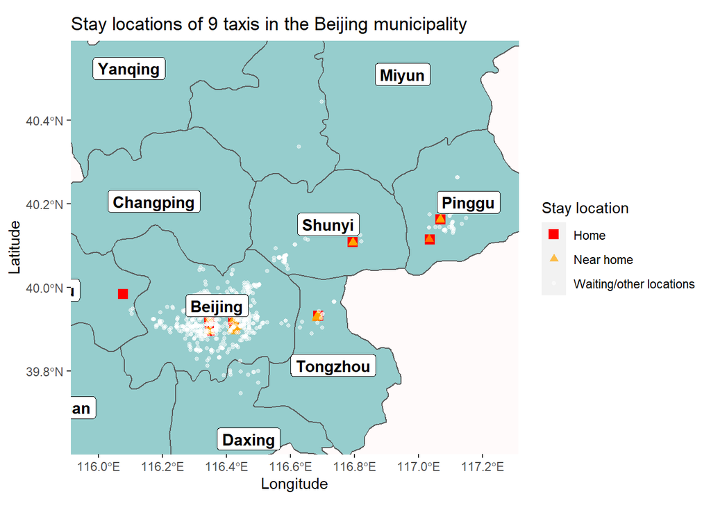

```r
beijing %>%
    filter(NAME_1 == "Beijing") %>% #only Beijing municipality

  ggplot() +

  geom_sf(fill="paleturquoise3") + # background colour in the map

  geom_sf(data=complete_stay_table, #stay_table as data

            # categorize colour, size and shape by stay_type
            aes(color=stay_type,
                size=stay_type,
                shape=stay_type)) +

  #shapes of stay_type
  scale_shape_manual(name = "Stay location",
                    labels = c("Home", "Near home", "Waiting/other locations"),
                    values=c(15,17,19)) +

  #colours of stay_type
  scale_color_manual(name = "Stay location",
                     labels = c("Home", "Near home", "Waiting/other locations"),
                     values=c('red',
                              alpha('orange', 0.7),
                              alpha('white', 0.5))) +

  #size of stay_type
  scale_size_manual(name = "Stay location",
                    labels = c("Home", "Near home", "Waiting/other locations"),
                    values=c(3,2,1)) +

  #bounding box limits defined by max and min lat and long
  coord_sf(xlim = c(st_bbox(complete_stay_table)[1] - 0.1,
                    st_bbox(complete_stay_table)[3] + 0.1),
           ylim = c(st_bbox(complete_stay_table)[2] - 0.1,
                    st_bbox(complete_stay_table)[4] + 0.1)) +

  #district label
  geom_sf_label(aes(label = NAME_3),
                colour = "black", fontface = "bold", size=4) +

  xlab("Longitude") + # x axis label
  ylab("Latitude") +  # y axis label

  #title of figure
  ggtitle(paste0("Stay locations of ",
                  length(unique(complete_trip_table$taxi_id)),
                  " taxis",
                  " in the Beijing municipality")) +

  #theme
  theme(panel.grid.major = element_blank(), # removes grid
        panel.background = element_rect(fill = "snow1")) # panel background
```

We can see that five out of nine home locations are present outside the Beijing district, whereas most of the waiting locations of the taxis are inside the Beijing district. At least, based on the trajectory data of these nine taxis, the taxi drivers seem to work more in the Beijing district.

To quantify the above results, we identify the number of waiting points per district by joining the waiting point GPS records with the Beijing shapefile.

```r
bej_mun <- china %>%
    filter(NAME_1 == "Beijing") #filter only Beijing

only_other <- complete_stay_table %>%
    filter(stay_type == "other_stay_points") # only other_stay_points

points_sf_joined <- st_join(only_other, bej_mun) %>% # merge stay table and Beijing shape files
  filter(!is.na(GID_0)) # removes values with NA

points_sf_joined %>%
  group_by(NAME_3) %>% #group by district
  tally() %>% # count points per district
  st_drop_geometry() %>% #drop geometry
  arrange(-n) %>% # re-order by n column

  #table in kable format
  kable(col.names = c("District", "Number of waiting points"),
        caption = "The number of waiting points of the taxis (n=9) by
        district of Beijing.")
```

The number of waiting points of the taxis (n=9) by district of Beijing.

| District | Number of waiting points |
| --- | --- |
| Beijing | 558 |
| Shunyi | 49 |
| Pinggu | 30 |
| Tongzhou | 12 |
| Daxing | 10 |
| Mentougou | 3 |
| Huairou | 2 |

Based on the above table, we can confirm that the Beijing district observed the highest number of waiting points.

Now, we will work with the complete trip table. First, we plot the number of trips done on each day of the week using the day of the week information extracted during the generation of the complete trip table.

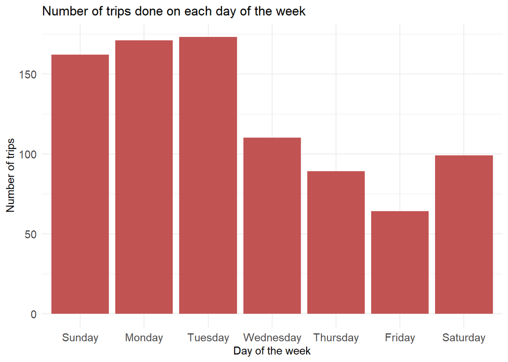

```r
complete_trip_table %>%

  group_by(week) %>% #group by week
  ggplot() +
  geom_bar(aes(x=week), fill = "#c25353") +                   # week values for bars and fill bar with colour
  ggtitle("Number of trips done on each day of the week") +   # title
  xlab("Day of the week") +                                   # x axis label
  ylab("Number of trips") +                                   # y axis label

  #custom x axis text labels
  scale_x_discrete(labels=c("6" ="Saturday", "0" = "Sunday", "1" = "Monday",
                            "2" = "Tuesday", "3" = "Wednesday",
                            "4" = "Thursday", "5" ="Friday")) +
  theme_minimal() + # theme

  #text size
  theme(text = element_text(size=11),
        axis.text.x = element_text(size=11),
        axis.text.y = element_text(size=11))
```

We can see that the number of trips done on Sunday, Monday, and Tuesday seems to be relatively higher compared to the rest of the days. The trips tend to gradually decline from Wednesday to Friday.

Now, we plot the number of trips that started and ended at each hour of the day. We also divide the day into 5 parts (morning, afternoon, evening, night, and late-night), and plot the number of trips that started and ended in each part of the day.

```r
trip_time_range <- complete_trip_table %>%
    select(stay_points_label, taxi_id, start_hr, end_hr) %>% #selects only respective columns

    pivot_longer(cols=c(start_hr, end_hr)) #flips the table so the start_hr and end_hr columns values merge into a new column (value) as observations including a respective label column (name) indicating the original column name

head(trip_time_range)
```

| stay_points_label | taxi_id | name | value |
| --- | --- | --- | --- |
| trip_1 | 48 | start_hr | 13 |
| trip_1 | 48 | end_hr | 21 |
| trip_10 | 48 | start_hr | 0 |
| trip_10 | 48 | end_hr | 1 |
| trip_11 | 48 | start_hr | 7 |
| trip_11 | 48 | end_hr | 8 |

```r
#creates new column defining the category of hour
trip_time_range <- trip_time_range %>% mutate(drop_hr_type = factor(case_when(
                                  value >= 0  & value <= 4 ~ "late_night", #if the hour is in between 0 and 4

                                  #if the hour is in between 5 and 10
                                  value >= 5  & value <= 10 ~ "morning",

                                  #if the hour is in between 11 and 15
                                  value >= 11 & value <= 15 ~ "afternoon",

                                  #if the hour is in between 16 and 20
                                  value >= 16 & value <= 20 ~ "evening",

                                  #if the hour is in between 21 and 23
                                  value >= 21 & value <=  23 ~ "night"),
                               levels = c('morning', 'afternoon',
                                         'evening', 'night', 'late_night'),
                               ordered=TRUE)) %>%

  #name column observation as factors
  mutate(name = factor(name, levels = c("start_hr","end_hr"), ordered = TRUE))

head(trip_time_range)
```

| stay_points_label | taxi_id | name | value | drop_hr_type |
| --- | --- | --- | --- | --- |
| trip_1 | 48 | start_hr | 13 | afternoon |
| trip_1 | 48 | end_hr | 21 | night |
| trip_10 | 48 | start_hr | 0 | late_night |
| trip_10 | 48 | end_hr | 1 | late_night |
| trip_11 | 48 | start_hr | 7 | morning |
| trip_11 | 48 | end_hr | 8 | morning |

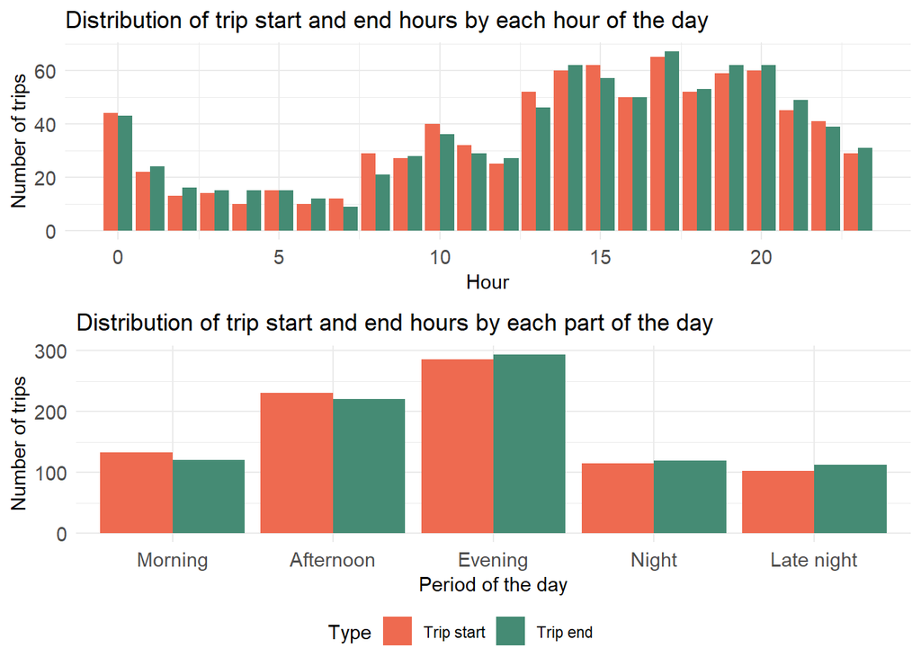

```r
one <- trip_time_range  %>%
    ggplot() +

    #geom bar plots the frequency count of each hour value
    geom_bar(aes(x=value, fill=name), position = "dodge") +  #dodge value plots bars side-by-side

    #custom legend name and colours
    scale_fill_manual(name = "Type",
                       labels = c("Trip start", "Trip end"),
                       values = c("coral2", "aquamarine4")) +

    #title of graph
    ggtitle("Distribution of trip start and end hours by each hour of the day") +
    xlab("Hour") + #x axis label
    ylab("Number of trips") + #y axis label
    theme_minimal() + #custom theme

    #theme text size values
    theme(text = element_text(size=11),

          axis.text.x = element_text(size=11),

          axis.text.y = element_text(size=11))


two <- trip_time_range  %>%
  ggplot() +

  #geom bar plots the frequency count of each time category value
  geom_bar(aes(x=drop_hr_type, fill=name), position = "dodge")+ #dodge value plots bars side-by-side
  #custom legend name and colors
  scale_fill_manual(name = "Type",
                       labels = c("Trip start", "Trip end"),
                       values = c("coral2", "aquamarine4")) +

  #title of graph
  ggtitle("Distribution of trip start and end hours by each part of the day") +
  xlab("Period of the day") + #x axis label
  ylab("Number of trips") + #y axis label
  scale_x_discrete(labels=c("afternoon" = "Afternoon", "evening" = "Evening",
                            "late_night" = "Late night", "morning" = "Morning",
                            "night" = "Night")) + #custom labels of x axis text
  theme_minimal() + #custom theme

  #theme text size values
  theme(text = element_text(size=11),

        axis.text.x = element_text(size=11),

        axis.text.y = element_text(size=11))


#plots the above two graphs one above other
ggarrange(one, two, nrow=2, common.legend = TRUE, legend="bottom")
```

From the top plot, we can see that the number of trips that start and end gradually increases from 8 am and observe the highest pickups and drops between 1 pm and 9 pm. The lowest number of trips are seen from 1 am to 7 am. When categorized by part of the day, the highest number of trips is observed in the evening.

We now divide the trips based on the trip duration (less than 15 minutes, 15-30 minutes, 30 minutes - 1 hour, 1-3 hours) and see the distribution of the trips based on these categories on each day of the week.

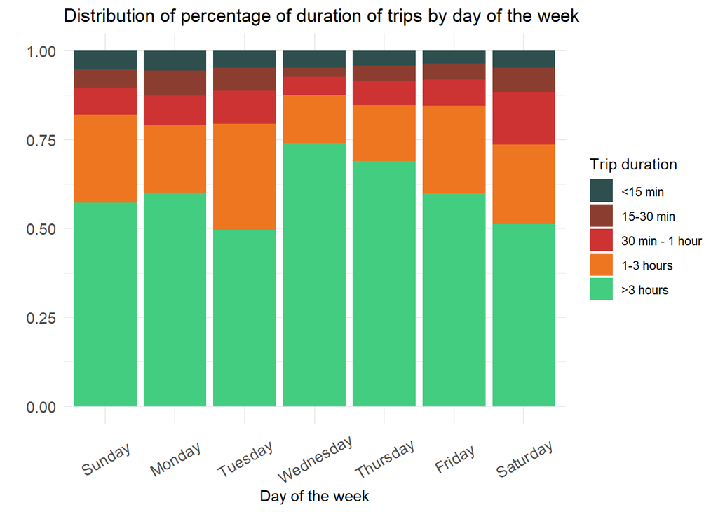

```r
complete_trip_table %>%
  select(trip_duration_hrs, week) %>% #selects only respective columns

  #new column with trip duration category
  mutate(category =
           #as factors
           factor(case_when(trip_duration_hrs >= 0  & trip_duration_hrs < 15/60 ~
                              "<15 min", #less than 15 minutes
                            trip_duration_hrs >= 15/60  & trip_duration_hrs <= 30/60 ~
                              "15-30 min", #between 15 and 30 minutes
                            trip_duration_hrs > 30/60  & trip_duration_hrs <= 1 ~
                              "30 min - 1 hour", #30 minutes to 1 hour
                            trip_duration_hrs > 1  & trip_duration_hrs <= 3 ~
                              "1-3 hours", #1 to 3 hours
                            trip_duration_hrs > 3  ~  ">3 hours",),

                  #levels
                  level = c("<15 min", "15-30 min",
                            "30 min - 1 hour", "1-3 hours", ">3 hours"),
                               ordered=TRUE)) %>%

  #groups by week and category
  group_by(week, category) %>%

  #adds trip duration hours for each category in each week
  summarise(total_duration = sum(trip_duration_hrs)) %>%

  ggplot() +

  #plots percentage (position=fill)
  geom_col(aes(x=week, y=total_duration, fill=category), position = "fill") +

  #custom legend name and colors
  scale_fill_manual(name = "Trip duration",
                       values = c("darkslategrey", "coral4", "brown3", "chocolate2", "seagreen3")) +

  #graph title
  ggtitle("Distribution of percentage of duration of trips by day of the week") +
  xlab("Day of the week") + # x axis label
  ylab("") + #y axis label

  #custom x axis labels
  scale_x_discrete(labels=c("0" = "Sunday", "1" = "Monday",
                            "2" = "Tuesday", "3" = "Wednesday",
                            "4" = "Thursday", "5" ="Friday",
                            "6" ="Saturday")) +
  theme_minimal() + #custom theme

  #theme text size values
  theme(text = element_text(size=11),

        axis.text.x = element_text(angle = 30, vjust = 0.5, size=11), #rotate labels

        axis.text.y = element_text(size=11))
```

Now, let’s try to build a **Least Squares Regression** model based on the aggregated trip table and predict the time duration when given a trip distance.

Before proceeding to build the model, we first try to plot the trip distances and trip duration using the geom_smooth function from ggplot.

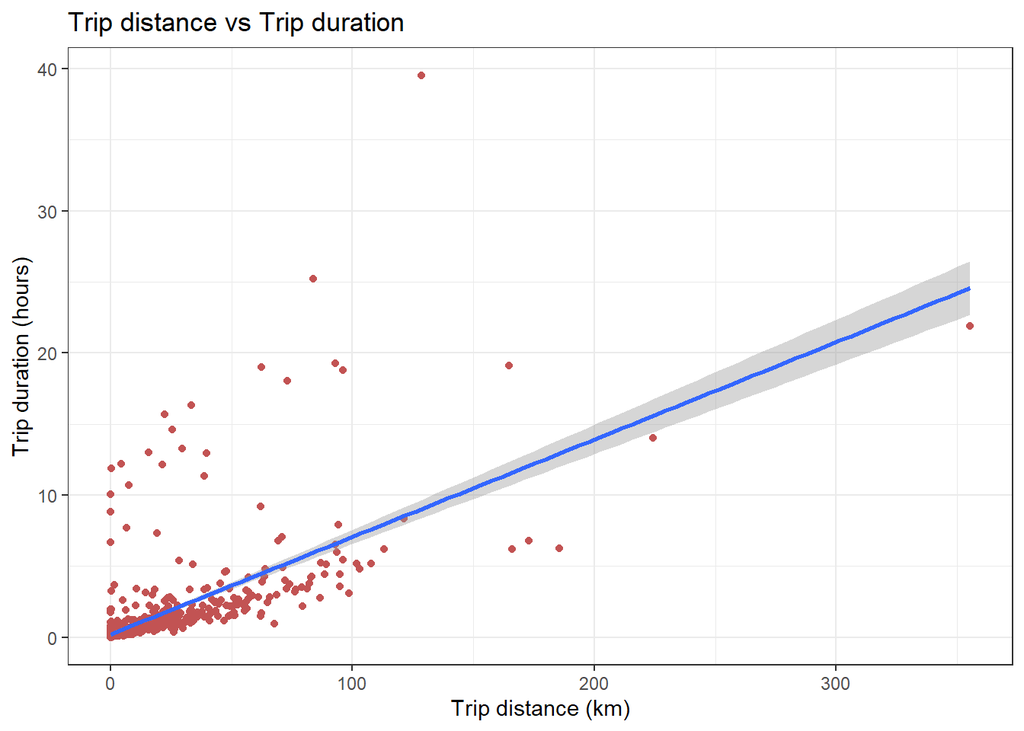

```r
#trip_distance vs trip_duration plot
complete_trip_table %>%
    ggplot() +

    #plot as points with specific colour
    geom_point(aes(trip_distance_kms, trip_duration_hrs), colour = "#c25353") +

    #plot as points with specific colour
    geom_smooth(aes(trip_distance_kms, trip_duration_hrs), method = lm) +
    theme_bw() + #custom theme
    xlab("Trip distance (km)") +
    ylab("Trip duration (hours)") +
    ggtitle("Trip distance vs Trip duration")
```

We seem to have a lot of outliers to build a Least Squares Regression model. Therefore, we log transform the values and re-plot the graph to see if we can eliminate the outliers and use only certain values to build the model.

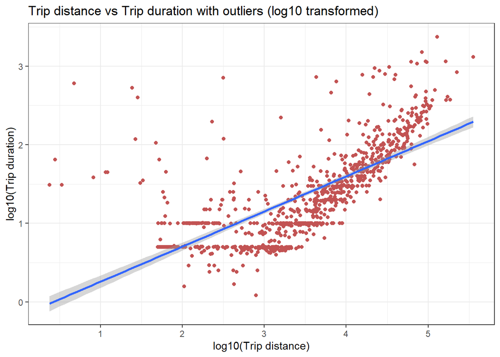

```r
forplot <- complete_trip_table %>%

  #new tibble
  summarise(trip_distance_kms = trip_distance_kms, #trip distance in km
            trip_distance_mtrs = trip_distance_kms*1000, #trip distance in meters

            trip_duration_hrs = trip_duration_hrs, #trip duration in hours
            trip_duration_min = trip_duration_hrs*60, #trip duration in minutes

            log_trip_distance_mtrs = trip_distance_mtrs, #duplicate of trip distance in meters
            log_trip_duration_min = trip_duration_min, #duplicate of trip duration in minutes

            #applying log10 to above duplicates
            across(c(log_trip_distance_mtrs, log_trip_duration_min),
                     log10)) %>%

  #removes values below 1 in 'trip distance meters' and 'trip duration in minutes'
  filter(trip_distance_mtrs >= 1 & trip_duration_min >= 1)


#trip_distance vs trip_duration plot (log10 transformed)
forplot %>%
    ggplot() +

    #plot as points with specific colour
    geom_point(aes(log_trip_distance_mtrs, log_trip_duration_min), colour = "#c25353") +

    #adds smoothing line
    geom_smooth(aes(log_trip_distance_mtrs, log_trip_duration_min), method = lm) +
    theme_bw() + #custom theme
    xlab("log10(Trip distance)") +
    ylab("log10(Trip duration)") +
    ggtitle("Trip distance vs Trip duration with outliers (log10 transformed)")
```

We see points less than 3.5 on log trip distance scale and less than 1 on log trip duration scale seems to be responsible for the worst fit. We delete all these points and use the rest of the points to build our regression model.

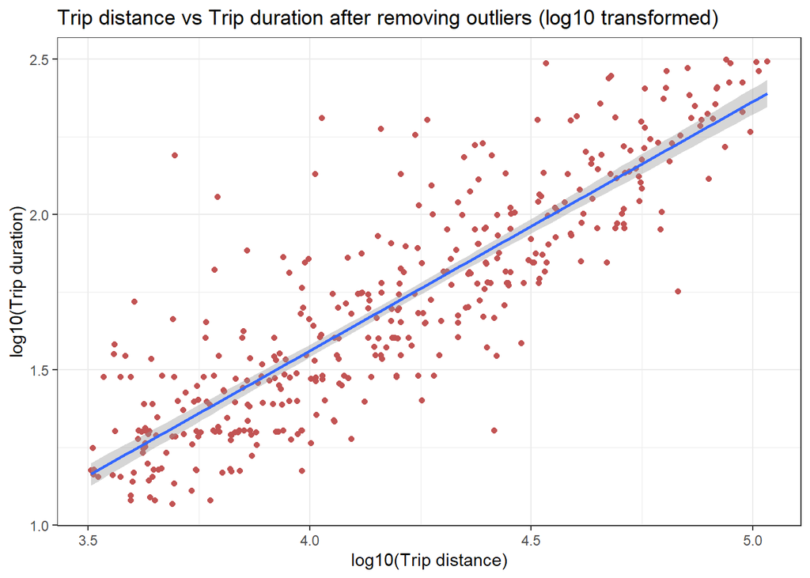

```r
#trip_distance vs trip_duration plot after filtering (log10 transformed)
forplot %>%

    #filtering
    filter(log_trip_distance_mtrs > 3.5 & (log_trip_duration_min < 2.5 &
                                        log_trip_duration_min > 1.01)) %>%
    ggplot() +

    #plot as points with specific colour
    geom_point(aes(log_trip_distance_mtrs, log_trip_duration_min), colour = "#c25353") +

    #adds smoothing line
    geom_smooth(aes(log_trip_distance_mtrs, log_trip_duration_min), method = lm) +
    theme_bw() +
    xlab("log10(Trip distance)") +
    ylab("log10(Trip duration)") +
    ggtitle("Trip distance vs Trip duration after removing outliers (log10 transformed)")
```

Before performing the regression, we do a correlation test between the trip distance and trip duration.

```r
corr <- forplot %>%

    #filtering
    filter(log_trip_distance_mtrs > 3.5 & (log_trip_duration_min < 2.5 &
                                        log_trip_duration_min > 1.01)) %>%

    #correlation test
    cor.test(~ trip_duration_hrs + trip_distance_kms, data=.) %>%
    tidy()

corr
```

| estimate | statistic | p.value | parameter | conf.low | conf.high | method | alternative |
| --- | --- | --- | --- | --- | --- | --- | --- |
| 0.8465163 | 31.48261 | 0.0000000000000000000000000000000000000000000000000000000000000000000000000000000000000000000000000000000000002240511 | 392 | 0.8159611 | 0.8723552 | Pearson's product-moment correlation | two.sided |

As seen in the above result, there exists a positive correlation with an estimate of 0.8465163 between trip distance and trip duration. That is, when the trip distance increases, the trip duration also tends to increase.

Now, with trip duration as our dependent variable and trip distance as our independent variable, we perform a Least Squares Regression analysis.

```r
LSR <- forplot %>%

  #filtering
  filter(log_trip_distance_mtrs > 3.5 & (log_trip_duration_min < 2.5 &
                                        log_trip_duration_min > 1.01)) %>%

  #Least Squares Regression
  zelig(trip_duration_min ~ trip_distance_kms, data=., model="ls", cite = FALSE)

LSR %>%
  from_zelig_model() %>%
  stargazer::stargazer(type="html") #html table format
```

|  | *Dependent variable:* |
| --- | --- |
|  | trip_duration_min |
| trip_distance_kms | 2.616*** |
|  | (0.083) |
| Constant | 13.355*** |
|  | (2.631) |
| Observations | 394 |
| R<sup>2</sup> | 0.717 |
| Adjusted R<sup>2</sup> | 0.716 |
| Residual Std. Error | 36.153 (df = 392) |
| F Statistic | 991.155*** (df = 1; 392) |
| *Note:* | p<0.1; p<0.05; p<0.01 |

As seen in the above regression result, our model states that to travel 1 kilometer, a duration of 2.6 minutes is required by the taxi. Although, we should note that our residual error (36.153) seems to be higher. It was already obvious that our model will not be perfect based on the above log-transformed Trip distance vs trip duration graph (without outliers). But we proceed to predict the duration of a trip when a distance is provided to our regression model.

```r
p_LSR <- LSR %>%
    setx(trip_distance_kms=5) %>% #predict duration for 5 km
    sim()

p_LSR
```

```
##
##  sim x :
##  -----
## ev
##       mean       sd      50%     2.5%    97.5%
## 1 26.48428 2.287784 26.59897 22.00434 31.15328
## pv
##          mean       sd      50%      2.5%    97.5%
## [1,] 26.54966 36.42234 26.48642 -46.83259 100.5389
```

As seen in the above result, a trip of **5 km** would take around **26.4 minutes** (Speed: **11.36 km/hour**) to complete. By a quick [Google search](https://qz.com/163178/a-big-reason-beijing-is-polluted-the-average-car-goes-7-5-miles-per-hour/), we can see that the average speed of a car in Beijing is around **12 km/hour**, which seems to be close to our result.

### 4. Conclusion

Our results are concluded based on only the 9 taxis information, but a similar analysis could apply to the 10,357 taxi trajectories available in the sample data set.

#### Software citations

1. *R* (R Core Team 2021)
2. *R Studio* (RStudio Team 2020)

#### Library citations

1. *rmarkdown* (Xie, Allaire, and Grolemund 2018) (Xie, Dervieux, and Riederer 2020) (Allaire et al. 2021)
2. *knitr* (Xie 2014) (Xie 2015) (Xie 2021)
3. *tidyverse* (Wickham et al. 2019)
4. *sf* (Tennekes 2021)
5. *lwgeom* (Pebesma 2021)
6. *ggplot2* (Wickham 2016)
7. *scales* (Wickham and Seidel 2020)
8. *lubridate* (Grolemund and Wickham 2011)
9. *hms* (Müller 2021)
10. *broom* (Robinson, Hayes, and Couch 2021)
11. *DT* (Xie, Cheng, and Tan 2021)
12. *mapview* (Appelhans et al. 2021)
13. *ggpubr* (Kassambara 2020)
14. *tmaptools* (Tennekes 2021)
15. *stargazer* (Hlavac 2018)
16. *Zelig* (Imai, King, and Lau 2008) (Choirat et al. 2020)

### References

Allaire, J J, Yihui Xie, Jonathan McPherson, Javier Luraschi, Kevin Ushey, Aron Atkins, Hadley Wickham, Joe Cheng, Winston Chang, and Richard Iannone. 2021. *rmarkdown: Dynamic Documents for R*. https://github.com/rstudio/rmarkdown.

Appelhans, Tim, Florian Detsch, Christoph Reudenbach, and Stefan Woellauer. 2021. *mapview: Interactive Viewing of Spatial Data in R*. https://cran.r-project.org/package=mapview.

Choirat, Christine, James Honaker, Kosuke Imai, Gary King, and Olivia Lau. 2020. *Zelig: Everyone’s Statistical Software*. https://zeligproject.org/.

Grolemund, Garrett, and Hadley Wickham. 2011. “Dates and Times Made Easy with lubridate.” *Journal of Statistical Software* 40 (3): 1–25. https://www.jstatsoft.org/v40/i03/.

Hlavac, Marek. 2018. *Stargazer: Well-Formatted Regression and Summary Statistics Tables*. Bratislava, Slovakia: Central European Labour Studies Institute (CELSI). https://CRAN.R-project.org/package=stargazer.

Imai, Kosuke, Gary King, and Olivia Lau. 2008. “Toward a Common Framework for Statistical Analysis and Development.” *Journal of Computational Graphics and Statistics* 17 (4): 892–913. https://gking.harvard.edu/files/abs/z-abs.shtml.

Kassambara, Alboukadel. 2020. *ggpubr: ’ggplot2’ Based Publication Ready Plots*. https://cran.r-project.org/package=ggpubr.

Li, Quannan, Yu Zheng, Xing Xie, Yukun Chen, Wenyu Liu, and Wei-Ying Ma. 2008. “Mining user similarity based on location history.” In *Proceedings of the 16th ACM SIGSPATIAL International Conference on Advances in Geographic Information Systems*, 1–10.

Müller, Kirill. 2021. *hms: Pretty Time of Day*. https://cran.r-project.org/package=hms.

Pebesma, Edzer. 2021. *lwgeom: Bindings to Selected ’liblwgeom’ Functions for Simple Features*. https://cran.r-project.org/package=lwgeom.

R Core Team. 2021. *R: A Language and Environment for Statistical Computing*. Vienna, Austria: R Foundation for Statistical Computing. https://www.r-project.org/.

Robinson, David, Alex Hayes, and Simon Couch. 2021. *broom: Convert Statistical Objects into Tidy Tibbles*. https://cran.r-project.org/package=broom.

RStudio Team. 2020. *RStudio: Integrated Development Environment for R*. Boston, MA: RStudio, PBC. http://www.rstudio.com/.

Tennekes, Martijn. 2021. *tmaptools: Thematic Map Tools*. https://cran.r-project.org/package=tmaptools.

Wickham, Hadley. 2016. *ggplot2: Elegant Graphics for Data Analysis*. Springer-Verlag New York. https://ggplot2.tidyverse.org.

Wickham, Hadley, Mara Averick, Jennifer Bryan, Winston Chang, Lucy D’Agostino McGowan, Romain François, Garrett Grolemund, et al. 2019. “Welcome to the tidyverse.” *Journal of Open Source Software* 4 (43): 1686. https://doi.org/10.21105/joss.01686.

Wickham, Hadley, and Dana Seidel. 2020. *scales: Scale Functions for Visualization*. https://cran.r-project.org/package=scales.

Xie, Yihui. 2014. “knitr: A Comprehensive Tool for Reproducible Research in R.” In *Implementing Reproducible Computational Research*, edited by Victoria Stodden, Friedrich Leisch, and Roger D Peng. Chapman; Hall/CRC. http://www.crcpress.com/product/isbn/9781466561595.

———. 2015. *Dynamic Documents with R and knitr*. 2nd ed. Boca Raton, Florida: Chapman; Hall/CRC. https://yihui.org/knitr/.

———. 2021. *knitr: A General-Purpose Package for Dynamic Report Generation in R*. https://yihui.org/knitr/.

Xie, Yihui, J J Allaire, and Garrett Grolemund. 2018. *R Markdown: The Definitive Guide*. Boca Raton, Florida: Chapman; Hall/CRC. https://bookdown.org/yihui/rmarkdown.

Xie, Yihui, Joe Cheng, and Xianying Tan. 2021. *DT: A Wrapper of the JavaScript Library ’DataTables’*. https://cran.r-project.org/package=DT.

Xie, Yihui, Christophe Dervieux, and Emily Riederer. 2020. *R Markdown Cookbook*. Boca Raton, Florida: Chapman; Hall/CRC. https://bookdown.org/yihui/rmarkdown-cookbook.

Yuan, Jing, Yu Zheng, Xing Xie, and Guangzhong Sun. 2011a. “Driving with knowledge from the physical world.” In *Proceedings of the 17th ACM SIGKDD International Conference on Knowledge Discovery and Data Mining*, 316–24.

———. 2011b. “T-drive: Enhancing driving directions with taxi drivers’ intelligence.” *IEEE Transactions on Knowledge and Data Engineering* 25 (1): 220–32.